# Text analysis hierarchy

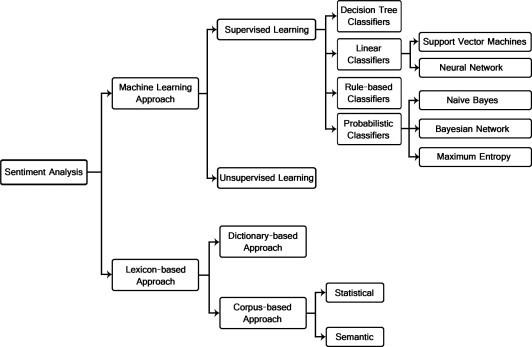

# Packages

## Main Packages:

- tm:
  - core library
  - text mining framework
  - http://tm.r-forge.r-project.org
  - ftp://cran.r-project.org/pub/R/web/packages/tm/vignettes/tm.pdf
- qdap:
  - designed to assist in quantitative discourse analysis
  - https://trinker.github.io/qdap/
- tidytext:
  - text mining in the “tidyverse”
  - http://tidytextmining.com/
- syuzhet:
  - An R package for the extraction of sentiment and sentiment-based plot arcs from text
  - has link to stanford sentiment
  - https://github.com/mjockers/syuzhet
  - ftp://cran.r-project.org/pub/R/web/packages/syuzhet/vignettes/syuzhet-vignette.html
- sentimentr:
  - similar to tidytext
  - trade off between speed an accuracy
    - faster than stanford, but not as accurate
    - slower than dictionaries, but more accurate
  - https://github.com/trinker/sentimentr
  - comparing syuzhet, rsentiment, and stanford: https://github.com/trinker/sentimentr#comparing-sentimentr-syuzhet-rsentiment-and-stanford

## Other packages:

- coreNLP:
  - Stanford library
  - “best” according to sentimentr and other sites
  - https://github.com/statsmaths/coreNLP
  - http://stanfordnlp.github.io/CoreNLP/

## Github packages:

- VADER:
  - specifically attuned to sentiments expressed in social media
  - https://github.com/cjhutto/vaderSentiment
- SpeedReader:
  - interested in heavy NLP applications in R, or working with an obscenely large corpus
  - https://github.com/matthewjdenny/SpeedReader
- sentiment140
  - R package for Twitter sentiment text analysis
  - https://github.com/okugami79/sentiment140

## Helper packages:

- SnowballC:
  - word stemming algorithm for collapsing words to a common root to aid comparison of vocabulary
  - `?SnowballC::wordStem`
  - https://github.com/nalimilan/R.TeMiS
- hunspell:
  - spell checker
  - http://hunspell.github.io
- tokenizers:
  - convert natural language text into tokens
  - https://github.com/ropensci/tokenizers

# Examples:

- rbloggers
  - https://www.r-bloggers.com/intro-to-text-analysis-with-r/
- basic text mining
  - https://rstudio-pubs-static.s3.amazonaws.com/31867_8236987cf0a8444e962ccd2aec46d9c3.html
- gentle intro (good explainations)
  - https://eight2late.wordpress.com/2015/05/27/a-gentle-introduction-to-text-mining-using-r/
- tm/qdap example
  - http://onepager.togaware.com/TextMiningO.pdf
- syuzhet:
  - http://juliasilge.com/blog/If-I-Loved-NLP-Less/
  - http://juliasilge.com/blog/You-Must-Allow-Me/